# Clasificacion_Clientes_Rilo_v2

A continuacion generaremos una exportacion de los clientes segmentados por cluster para entrega al cliente.

```python
resultados_kmeans = KMeans(n_clusters = 3).fit(datos_std)
```

```python
labels = resultados_kmeans.predict(datos_std)
```

```python
resultados_kmeans.labels_
```

```
array([0, 0, 0, ..., 1, 1, 0], dtype=int32)
```

```python
df_Rilo_Clientes_ERP_clean_2["cluster"] = labels
```

```python
df_Rilo_Clientes_ERP_clean_2
```

|  | IDCliente | VENTASCLIENTE | NArticulos | NContratos | PrecMedArticulo | cluster |
| --- | --- | --- | --- | --- | --- | --- |
| 2 | 120003 | 392.28 | 21.50 | 19 | 20.356842 | 0 |
| 5 | 150003 | 295.34 | 13.00 | 13 | 22.718461 | 0 |
| 8 | 180003 | 239.84 | 12.00 | 12 | 19.986666 | 0 |
| 9 | 190002 | 388.83 | 24.25 | 9 | 39.475555 | 1 |
| 10 | 200004 | 154.53 | 6.00 | 6 | 25.755000 | 0 |
| ... | ... | ... | ... | ... | ... | ... |
| 3888 | 63450002 | 426.34 | 62.00 | 10 | 31.194000 | 1 |
| 3889 | 63460002 | 65.72 | 7.00 | 7 | 9.388571 | 0 |
| 3890 | 63480002 | 215.54 | 5.00 | 5 | 43.108000 | 1 |
| 3891 | 63500002 | 246.54 | 5.00 | 5 | 49.308000 | 1 |
| 3900 | 63780002 | 58.58 | 4.00 | 4 | 14.645000 | 0 |

2050 rows × 6 columns

```python
df_Rilo_Clientes_ERP_clean_2.to_csv("/content/drive/MyDrive/Colab Notebooks/Clasificador/Clasificación_Clientes_ERP.csv", index=True, header=True, float_format='%.3f')
```

```python
df_Rilo_Clientes_ERP_clean_2.to_excel("/content/drive/MyDrive/Colab Notebooks/Clasificador/Clasificación_Clientes_ERP.xlsx", index=True, header=True, float_format='%.3f')
```

```python
df_Rilo_Clientes_ERP_clean_2.describe()
```

|  | IDCliente | VENTASCLIENTE | NArticulos | NContratos | PrecMedArticulo | cluster |
| --- | --- | --- | --- | --- | --- | --- |
| count | 2.050000e+03 | 2050.000000 | 2050.000000 | 2050.000000 | 2050.000000 | 2050.000000 |
| mean | 3.360922e+07 | 267.012654 | 21.187141 | 11.539024 | 23.779040 | 0.617561 |
| std | 1.772172e+07 | 255.228648 | 25.438390 | 9.904507 | 13.702158 | 0.751822 |
| min | 1.200030e+05 | 50.000000 | 2.000000 | 2.000000 | 0.437500 | 0.000000 |
| 25% | 2.162250e+07 | 89.942500 | 5.000000 | 5.000000 | 12.715778 | 0.000000 |
| 50% | 3.413000e+07 | 184.800000 | 10.000000 | 8.000000 | 21.489487 | 0.000000 |
| 75% | 4.836500e+07 | 333.270000 | 25.000000 | 15.000000 | 32.053125 | 1.000000 |
| max | 6.378000e+07 | 1504.720000 | 144.000000 | 56.000000 | 70.775000 | 2.000000 |

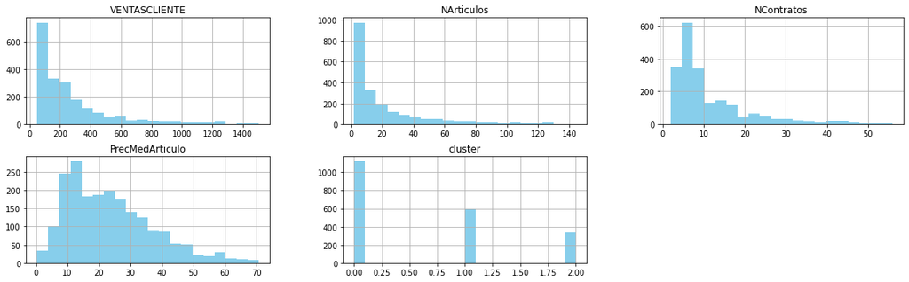

```python
df_Rilo_Clientes_ERP_clean_2.drop(['IDCliente'], axis=1).hist(color='skyblue', bins=20, layout=(11,3), figsize=(20,35));
```

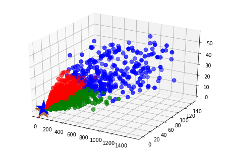

```python
df_Rilo_Clientes_ERP_clean_2_plot=df_Rilo_Clientes_ERP_clean_2.drop(['IDCliente','cluster'], axis=1)
C = resultados_kmeans.cluster_centers_
colores=['red','green','blue']
asignar=[]
for row in labels:
    asignar.append(colores[row])

fig = plt.figure()
ax = Axes3D(fig)
ax.scatter(df_Rilo_Clientes_ERP_clean_2_plot[df_Rilo_Clientes_ERP_clean_2_plot.columns[0]], df_Rilo_Clientes_ERP_clean_2_plot[df_Rilo_Clientes_ERP_clean_2_plot.columns[1]], df_Rilo_Clientes_ERP_clean_2_plot[df_Rilo_Clientes_ERP_clean_2_plot.columns[2]], c=asignar,s=60)
ax.scatter(C[:, 0], C[:, 1], C[:, 2], marker='*', c=colores, s=1000)
```

A continuacion vamos a realizar el anaisis con todas las variables eliminando los NA de los campos que no disponemos valores procedentes del proveedor CESCE

```python
df_Rilo_Clientes_Clean_2.info()
```

```
<class 'pandas.core.frame.DataFrame'>
Int64Index: 2487 entries, 0 to 3900
Data columns (total 27 columns):
 #   Column                           Non-Null Count  Dtype
---  ------                           --------------  -----
 0   Unnamed: 0                       2487 non-null   int64
 1   City                             1051 non-null   object
 2   State                            1064 non-null   object
 3   Postal Code                      1069 non-null   float64
 4   Credit Limit Requested           1071 non-null   float64
 5   Payment Method Requested Code    1071 non-null   float64
 6   Credit Limit Granted             1071 non-null   float64
 7   Commercial Risk Cover Protected  1071 non-null   float64
 8   Commercial Risk Group Code       1071 non-null   float64
 9   Payment Method Granted           1071 non-null   float64
```

[output cut: 19 more lines]

```python
df_Rilo_Clientes_Clean_2.shape
```

```
(2487, 27)
```

```python
df_Rilo_Clientes_Clean_3 = df_Rilo_Clientes_Clean_2.drop(['Unnamed: 0','City', 'Status',
                                              'ClientePadre','State','Classification Decision','Request Entry Date','Effective Date'], axis=1)
df_Rilo_Clientes_Clean_3.head(5)
```

|  | Postal Code | Credit Limit Requested | Payment Method Requested Code | Credit Limit Granted | Commercial Risk Cover Protected | Commercial Risk Group Code | Payment Method Granted | Payment Terms Granted | Status Code | Classification Decision Code | IDCliente | VENTASCLIENTE | MBAvg | MBMax | MBMin | NArticulos | NContratos | PrecMedArticulo | DifCPrevCReal |
| --- | --- | --- | --- | --- | --- | --- | --- | --- | --- | --- | --- | --- | --- | --- | --- | --- | --- | --- | --- |
| 0 | NaN | NaN | NaN | NaN | NaN | NaN | NaN | NaN | NaN | NaN | 80002 | 4088.0932 | 32.83660 | 100.0 | -1206.010 | 692.5 | 224 | 15.130683 | -3.0 |
| 1 | 15542.0 | 45000.0 | 99.0 | 0.0 | 0.0 | 0.0 | 0.0 | 0.0 | 2.0 | 58.0 | 110007 | 830.1700 | -3.13485 | 100.0 | -816.492 | 121.0 | 121 | 6.860909 | -39.0 |
| 2 | NaN | NaN | NaN | NaN | NaN | NaN | NaN | NaN | NaN | NaN | 120003 | 392.2800 | 3.70088 | 100.0 | -630.395 | 21.5 | 19 | 20.356842 | 7.0 |
| 3 | 15404.0 | 45000.0 | 99.0 | 0.0 | 0.0 | 0.0 | 0.0 | 0.0 | 2.0 | 35.0 | 130030 | 2402.7208 | 73.62650 | 100.0 | -1206.010 | 373.0 | 165 | 11.935398 | 8.0 |
| 4 | 15404.0 | 45000.0 | 99.0 | 45000.0 | 95.0 | 1.0 | 99.0 | 180.0 | 66.0 | 23.0 | 140010 | 2044.0675 | 31.62250 | 100.0 | -816.492 | 202.5 | 94 | 18.651462 | 0.0 |

```python
df_Rilo_Clientes_Clean_3 = df_Rilo_Clientes_Clean_3.dropna()
df_Rilo_Clientes_Clean_3.info()
```

```
<class 'pandas.core.frame.DataFrame'>
Int64Index: 1038 entries, 1 to 3891
Data columns (total 19 columns):
 #   Column                           Non-Null Count  Dtype
---  ------                           --------------  -----
 0   Postal Code                      1038 non-null   float64
 1   Credit Limit Requested           1038 non-null   float64
 2   Payment Method Requested Code    1038 non-null   float64
 3   Credit Limit Granted             1038 non-null   float64
 4   Commercial Risk Cover Protected  1038 non-null   float64
 5   Commercial Risk Group Code       1038 non-null   float64
 6   Payment Method Granted           1038 non-null   float64
 7   Payment Terms Granted            1038 non-null   float64
 8   Status Code                      1038 non-null   float64
 9   Classification Decision Code     1038 non-null   float64
 10  IDCliente                        1038 non-null   int64
 11  VENTASCLIENTE                    1038 non-null   float64
 12  MBAvg                            1038 non-null   float64
 13  MBMax                            1038 non-null   float64
 14  MBMin                            1038 non-null   float64
 15  NArticulos                       1038 non-null   float64
 16  NContratos                       1038 non-null   int64
 17  PrecMedArticulo                  1038 non-null   float64
 18  DifCPrevCReal                    1038 non-null   float64
dtypes: float64(17), int64(2)
memory usage: 162.2 KB
```

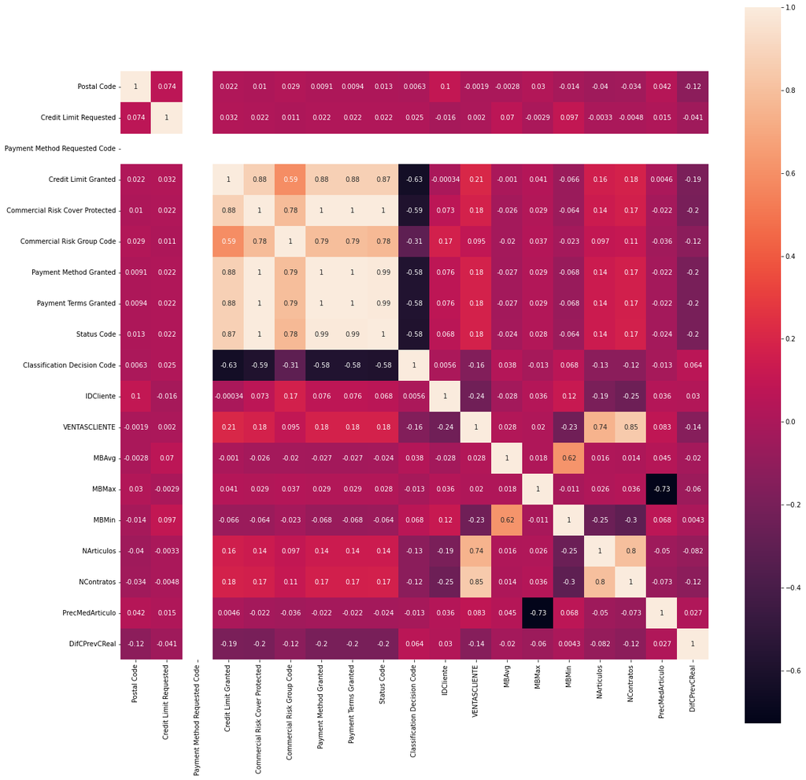

```python
corr = df_Rilo_Clientes_Clean_3.corr()
corr.shape

plt.figure(figsize=(20,20))
sns.heatmap(corr, cbar=True, square=True, annot=True)
```

Seleccionamos unicamente las columnas que disponen de relacion para pasar a realizar analisis de clustering

```python
df_Rilo_Clientes_Clean_4 = df_Rilo_Clientes_Clean_3.loc[:, ['Credit Limit Granted', 'Commercial Risk Cover Protected', 'Commercial Risk Group Code',
                                                            'Payment Method Granted','Payment Terms Granted','Status Code','IDCliente','VENTASCLIENTE',
                                                            'NArticulos','NContratos']]
df_Rilo_Clientes_Clean_4.head()
```

|  | Credit Limit Granted | Commercial Risk Cover Protected | Commercial Risk Group Code | Payment Method Granted | Payment Terms Granted | Status Code | IDCliente | VENTASCLIENTE | NArticulos | NContratos |
| --- | --- | --- | --- | --- | --- | --- | --- | --- | --- | --- |
| 1 | 0.0 | 0.0 | 0.0 | 0.0 | 0.0 | 2.0 | 110007 | 830.1700 | 121.0 | 121 |
| 3 | 0.0 | 0.0 | 0.0 | 0.0 | 0.0 | 2.0 | 130030 | 2402.7208 | 373.0 | 165 |
| 4 | 45000.0 | 95.0 | 1.0 | 99.0 | 180.0 | 66.0 | 140010 | 2044.0675 | 202.5 | 94 |
| 5 | 0.0 | 0.0 | 0.0 | 0.0 | 0.0 | 2.0 | 150003 | 295.3400 | 13.0 | 13 |
| 8 | 20000.0 | 95.0 | 3.0 | 99.0 | 180.0 | 66.0 | 180003 | 239.8400 | 12.0 | 12 |

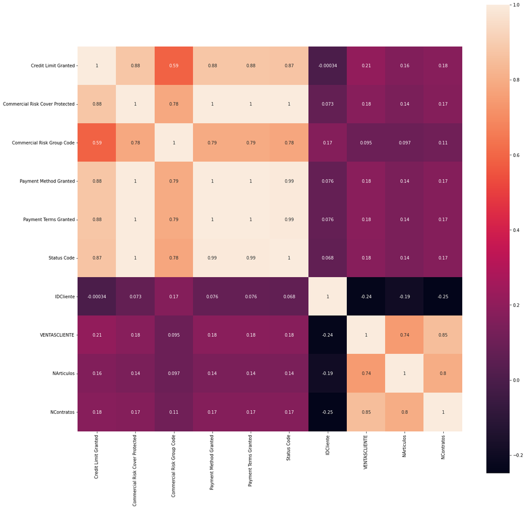

```python
corr = df_Rilo_Clientes_Clean_4.corr()
corr.shape

plt.figure(figsize=(20,20))
sns.heatmap(corr, cbar=True, square=True, annot=True)
```

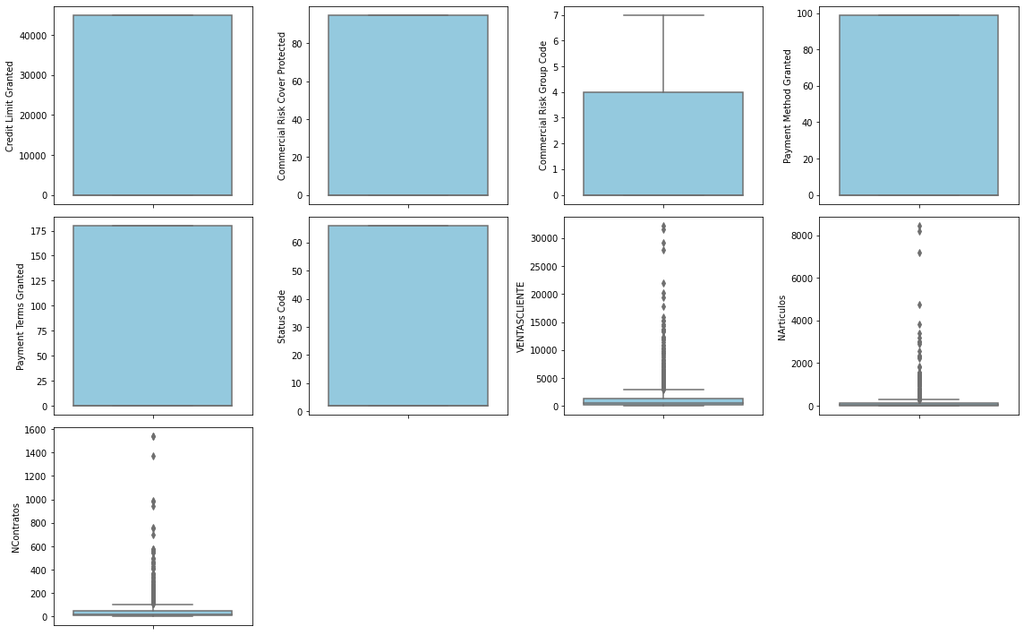

```python
plt.figure(figsize=(16,10))

for i,col in enumerate(df_Rilo_Clientes_Clean_4.drop(['IDCliente'], axis=1)):
    plt.subplot(3,4,i + 1)
    sns.boxplot(y=col, data=df_Rilo_Clientes_Clean_4.drop(['IDCliente'], axis=1), color='skyblue')

plt.tight_layout()

plt.show()
```

```python
df_Rilo_Clientes_Clean_4.describe(include = 'all')
```

|  | Credit Limit Granted | Commercial Risk Cover Protected | Commercial Risk Group Code | Payment Method Granted | Payment Terms Granted | Status Code | IDCliente | VENTASCLIENTE | NArticulos | NContratos |
| --- | --- | --- | --- | --- | --- | --- | --- | --- | --- | --- |
| count | 1038.000000 | 1038.000000 | 1038.000000 | 1038.000000 | 1038.000000 | 1038.000000 | 1.038000e+03 | 1038.000000 | 1038.000000 | 1038.000000 |
| mean | 17672.447013 | 46.695568 | 1.711946 | 49.023121 | 89.104046 | 33.356455 | 2.472332e+07 | 1487.341940 | 182.329592 | 55.398844 |
| std | 20356.765690 | 47.333078 | 2.182792 | 49.521563 | 90.014821 | 31.977483 | 1.939112e+07 | 3079.735984 | 578.007351 | 126.136603 |
| min | 0.000000 | 0.000000 | 0.000000 | 0.000000 | 0.000000 | 2.000000 | 1.100070e+05 | 50.250000 | 1.000000 | 1.000000 |
| 25% | 0.000000 | 0.000000 | 0.000000 | 0.000000 | 0.000000 | 2.000000 | 6.150003e+06 | 223.182500 | 13.000000 | 7.000000 |
| 50% | 0.000000 | 0.000000 | 0.000000 | 0.000000 | 0.000000 | 2.000000 | 2.257000e+07 | 482.359000 | 37.000000 | 18.000000 |
| 75% | 45000.000000 | 95.000000 | 4.000000 | 99.000000 | 180.000000 | 66.000000 | 3.998750e+07 | 1318.941375 | 123.000000 | 46.000000 |
| max | 45000.000000 | 95.000000 | 7.000000 | 99.000000 | 180.000000 | 66.000000 | 6.350000e+07 | 32216.492000 | 8443.000000 | 1538.000000 |

```python
df_Rilo_Clientes_Clean_4.shape
```

```
(1038, 10)
```

De igual modo que en el caso de los datos del ERP, disponemos de una gran cantidad de outliers que los trataremos con el mismo metodo que en el caso anterior.

En este caso se ha modificado el cuartil para aumentarlo en un 5% ya que se han simulado diferentes escenarios (70%,75%,80% y 85%) y estableciendo el limite en 80% es como la muestra presenta mas homogeneidad.

```python
Q1 = df_Rilo_Clientes_Clean_4.quantile(0.25)
Q3 = df_Rilo_Clientes_Clean_4.quantile(0.80)
IQR = Q3 - Q1
print(IQR)
```

```
Credit Limit Granted               4.500000e+04
Commercial Risk Cover Protected    9.500000e+01
Commercial Risk Group Code         4.000000e+00
Payment Method Granted             9.900000e+01
Payment Terms Granted              1.800000e+02
Status Code                        6.400000e+01
IDCliente                          3.884000e+07
VENTASCLIENTE                      1.519599e+03
NArticulos                         1.541500e+02
NContratos                         5.760000e+01
dtype: float64
```

```python
df_numerico = df_Rilo_Clientes_Clean_4
```

```python
df_numerico =(df_numerico < (Q1 - 2 * IQR)) |(df_numerico > (Q3 + 2 * IQR))
df_numerico.head(5)
```

|  | Credit Limit Granted | Commercial Risk Cover Protected | Commercial Risk Group Code | Payment Method Granted | Payment Terms Granted | Status Code | IDCliente | VENTASCLIENTE | NArticulos | NContratos |
| --- | --- | --- | --- | --- | --- | --- | --- | --- | --- | --- |
| 1 | False | False | False | False | False | False | False | False | False | False |
| 3 | False | False | False | False | False | False | False | False | False | False |
| 4 | False | False | False | False | False | False | False | False | False | False |
| 5 | False | False | False | False | False | False | False | False | False | False |
| 8 | False | False | False | False | False | False | False | False | False | False |

```python
count = 0
indice = []
for row in range(len(df_numerico)):
    if True not in np.array(df_numerico.iloc[row, :]):
        indice.append(count)
    count = count + 1
```

```python
df_Rilo_Clientes_Clean_4 = df_Rilo_Clientes_Clean_4.iloc[indice, : ]
```

```python
df_Rilo_Clientes_Clean_4.shape
```

```
(922, 10)
```

Despues de aplicar las técnicas de tratamiento de outliers la dimensión del dataset es de 922 frente a los 1038 iniciales. Estas medidas representan una perdida del 11% del dataset.

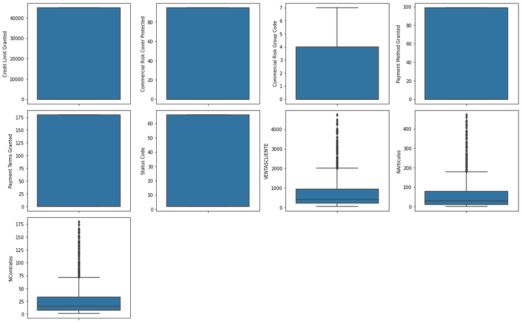

```python
plt.figure(figsize=(16,10))

for i,col in enumerate(df_Rilo_Clientes_Clean_4.drop(['IDCliente'], axis=1)):
    plt.subplot(3,4,i + 1)
    sns.boxplot(y=col, data=df_Rilo_Clientes_Clean_4.drop(['IDCliente'], axis=1))

plt.tight_layout()

plt.show()
```

```python
std = StandardScaler()
datos_std = std.fit_transform(df_Rilo_Clientes_Clean_4)
```

```python
clusters = range(2,20)

listado_silhouette = []
listado_clusters = []
lista_codo = []
for numero_clusters in clusters:
    resultado_kmeans = KMeans(n_clusters = numero_clusters).fit(datos_std)

    listado_clusters.append(numero_clusters)


    listado_silhouette.append(silhouette_score(datos_std, resultado_kmeans.labels_))


    lista_codo.append(sum(np.min(cdist(datos_std, resultado_kmeans.cluster_centers_), axis=1)) / datos_std.shape[0])
```

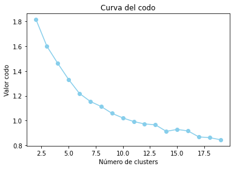

```python
plt.plot(listado_clusters, lista_codo, 'o-', color='skyblue')
plt.xlabel('Número de clusters')
plt.ylabel('Valor codo')
plt.title('Curva del codo')
plt.show()
```

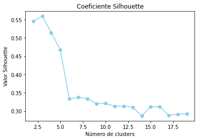

```python
plt.plot(listado_clusters, listado_silhouette, 'o-', color='skyblue')
plt.xlabel('Número de clusters')
plt.ylabel('Valor Silhouette')
plt.title('Coeficiente Silhouette')
plt.show()
```

```python
resultados_kmeans = KMeans(n_clusters = 6).fit(datos_std)
```

```python
labels = resultados_kmeans.predict(datos_std)
```

```python
resultados_kmeans.labels_
```

```
array([3, 3, 0, 4, 2, 2, 4, 2, 2, 4, 4, 4, 2, 0, 4, 2, 2, 4, 2, 0, 2, 0,
       0, 2, 4, 0, 2, 0, 4, 4, 2, 2, 2, 4, 2, 4, 4, 4, 4, 4, 4, 2, 2, 2,
       4, 2, 2, 4, 4, 2, 2, 4, 2, 3, 2, 2, 2, 0, 4, 4, 3, 0, 0, 3, 4, 4,
       3, 0, 2, 2, 2, 0, 0, 2, 4, 3, 2, 2, 4, 2, 0, 4, 4, 0, 2, 3, 4, 2,
       4, 2, 4, 4, 3, 0, 3, 4, 4, 2, 2, 0, 4, 0, 4, 0, 4, 4, 2, 0, 0, 0,
       2, 0, 4, 0, 4, 2, 0, 2, 2, 2, 2, 3, 2, 2, 4, 4, 0, 2, 0, 2, 3, 4,
       4, 0, 0, 3, 4, 2, 4, 4, 2, 4, 2, 4, 2, 0, 2, 0, 2, 2, 2, 4, 3, 0,
       4, 4, 4, 2, 0, 0, 4, 0, 4, 4, 2, 4, 4, 0, 2, 4, 2, 3, 2, 2, 0, 4,
       3, 2, 4, 2, 4, 2, 4, 4, 4, 4, 4, 0, 2, 2, 3, 3, 4, 4, 2, 4, 4, 0,
       4, 0, 2, 2, 2, 4, 2, 2, 4, 2, 2, 4, 2, 4, 2, 4, 4, 0, 4, 0, 2, 4,
       0, 2, 2, 2, 4, 4, 2, 0, 2, 3, 2, 4, 4, 4, 2, 4, 4, 2, 4, 0, 2, 4,
       4, 2, 2, 0, 4, 4, 4, 0, 4, 4, 4, 2, 4, 4, 0, 4, 2, 4, 4, 4, 4, 2,
       0, 2, 2, 4, 2, 2, 2, 4, 4, 2, 4, 4, 2, 4, 4, 2, 4, 4, 4, 0, 4, 4,
       4, 4, 4, 4, 4, 4, 4, 4, 4, 4, 4, 2, 0, 2, 2, 4, 3, 2, 2, 4, 4, 4,
       2, 2, 2, 2, 4, 2, 4, 2, 0, 4, 4, 0, 4, 0, 4, 2, 4, 2, 4, 2, 4, 4,
```

[output cut: 28 more lines]

```python
df_Rilo_Clientes_Clean_4["cluster"] = labels
```

```python
df_Rilo_Clientes_Clean_4
```

|  | Credit Limit Granted | Commercial Risk Cover Protected | Commercial Risk Group Code | Payment Method Granted | Payment Terms Granted | Status Code | IDCliente | VENTASCLIENTE | NArticulos | NContratos | cluster |
| --- | --- | --- | --- | --- | --- | --- | --- | --- | --- | --- | --- |
| 1 | 0.0 | 0.0 | 0.0 | 0.0 | 0.0 | 2.0 | 110007 | 830.1700 | 121.0 | 121 | 3 |
| 3 | 0.0 | 0.0 | 0.0 | 0.0 | 0.0 | 2.0 | 130030 | 2402.7208 | 373.0 | 165 | 3 |
| 4 | 45000.0 | 95.0 | 1.0 | 99.0 | 180.0 | 66.0 | 140010 | 2044.0675 | 202.5 | 94 | 0 |
| 5 | 0.0 | 0.0 | 0.0 | 0.0 | 0.0 | 2.0 | 150003 | 295.3400 | 13.0 | 13 | 4 |
| 8 | 20000.0 | 95.0 | 3.0 | 99.0 | 180.0 | 66.0 | 180003 | 239.8400 | 12.0 | 12 | 2 |
| ... | ... | ... | ... | ... | ... | ... | ... | ... | ... | ... | ... |
| 3874 | 20000.0 | 95.0 | 5.0 | 99.0 | 180.0 | 66.0 | 63220002 | 225.4500 | 5.0 | 5 | 5 |
| 3875 | 38000.0 | 95.0 | 4.0 | 99.0 | 180.0 | 66.0 | 63240002 | 253.7400 | 9.0 | 9 | 5 |
| 3886 | 45000.0 | 95.0 | 5.0 | 99.0 | 180.0 | 66.0 | 63420002 | 191.8500 | 17.0 | 6 | 5 |
| 3888 | 45000.0 | 95.0 | 3.0 | 99.0 | 180.0 | 66.0 | 63450002 | 426.3400 | 62.0 | 10 | 5 |
| 3891 | 45000.0 | 95.0 | 5.0 | 99.0 | 180.0 | 66.0 | 63500002 | 246.5400 | 5.0 | 5 | 5 |

922 rows × 11 columns

```python
df_Rilo_Clientes_Clean_4.describe()
```

|  | Credit Limit Granted | Commercial Risk Cover Protected | Commercial Risk Group Code | Payment Method Granted | Payment Terms Granted | Status Code | IDCliente | VENTASCLIENTE | NArticulos | NContratos | cluster |
| --- | --- | --- | --- | --- | --- | --- | --- | --- | --- | --- | --- |
| count | 922.000000 | 922.000000 | 922.000000 | 922.000000 | 922.000000 | 922.000000 | 9.220000e+02 | 922.000000 | 922.000000 | 922.000000 | 922.000000 |
| mean | 16419.739696 | 44.013015 | 1.622560 | 46.171367 | 83.947939 | 31.533623 | 2.638080e+07 | 729.512091 | 64.380889 | 27.527115 | 2.655098 |
| std | 20070.845228 | 47.242666 | 2.167435 | 49.414761 | 89.845020 | 31.892522 | 1.935942e+07 | 822.974014 | 85.004191 | 32.304500 | 1.712926 |
| min | 0.000000 | 0.000000 | 0.000000 | 0.000000 | 0.000000 | 2.000000 | 1.100070e+05 | 50.250000 | 1.000000 | 1.000000 | 0.000000 |
| 25% | 0.000000 | 0.000000 | 0.000000 | 0.000000 | 0.000000 | 2.000000 | 7.087505e+06 | 205.450000 | 11.000000 | 7.000000 | 1.000000 |
| 50% | 0.000000 | 0.000000 | 0.000000 | 0.000000 | 0.000000 | 2.000000 | 2.474500e+07 | 394.790000 | 29.000000 | 15.000000 | 2.000000 |
| 75% | 45000.000000 | 95.000000 | 4.000000 | 99.000000 | 180.000000 | 66.000000 | 4.187750e+07 | 927.075625 | 78.781250 | 33.000000 | 4.000000 |
| max | 45000.000000 | 95.000000 | 7.000000 | 99.000000 | 180.000000 | 66.000000 | 6.350000e+07 | 4743.430000 | 471.750000 | 179.000000 | 5.000000 |

```python
df_Rilo_Clientes_Clean_4.to_csv("/content/drive/MyDrive/Colab Notebooks/Clasificador/Clasificación_Clientes_MERGE.csv")
```

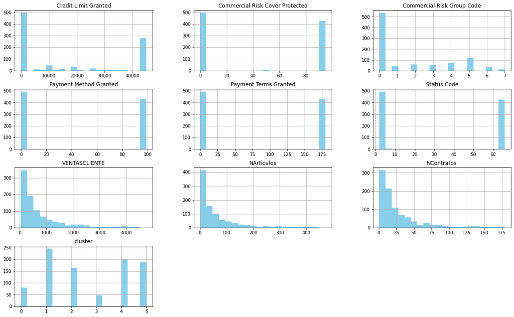

```python
df_Rilo_Clientes_Clean_4.drop(['IDCliente'], axis=1).hist(color='skyblue', bins=20, layout=(11,3), figsize=(20,35));
```

```python
df_Rilo_Clientes_Clean_4.to_csv("/content/drive/MyDrive/Colab Notebooks/Clasificador/Clasificación_Clientes_MERGE.csv")
```

```python
df_Rilo_Clientes_Clean_4.to_excel("/content/drive/MyDrive/Colab Notebooks/Clasificador/Clasificación_Clientes_MERGE.xlsx", index=True, header=True, float_format='%.3f')
```